# AnalizaWW_PD1

Maciej Nasinski

November 16, 2015

# FOTOGRAFIA SUKCESU - ANALIZA KANONICZNA

Za pomoca klasycznych wspólczynników korelacji oraz analizy kanonicznej zabadono zaleznosc pomiedzy zmiennymi opisujacymi ocene oraz cechy zdjec zamieszczonych na serwisie internetowym. Wnioskowanie pozwolilo na odnalezienie kilku interesujacych zaleznosci.

```r
library(moments)
library(CCA)
library(ggplot2)
```

Badanie zaczynamy od wgrania oraz obróbki danych. Poczatkowo zakladamy iz wszystkie zmienne sa typu “numeric” co pozwoli na strorzenie macierzy. Nastepnie tworzymy nowy data frame w którym konkretne zmienne formatujemy na typ “factor” z odpowiednio przypisanymi “levels”.

```r
setwd("C:/Users/MACIEK/Desktop/analizaWW/AWWPD1")
zdjecia <- read.csv("zdjecia.csv", sep = ";", header = TRUE, colClasses = c(rep("numeric",
    11)), row.names = 4)
zdjecia0 <- zdjecia
skalarad <- c("b.slabo", "slabo", "przecietnie", "dobrze", "b.dobrze", "rewelacyjnie")
# loop across 3-factor var. with the same levels
factors <- sapply(c(5, 8, 9), function(x) zdjecia[, x] <<- factor(zdjecia[,
    x], labels = skalarad))
# factor - kolor
zdjecia$kolor <- factor((zdjecia$kolor), labels = c("fioletowy", "zielony",
    "niebieski", "inny"))
# factor - miejsce
zdjecia$miejsce <- factor((zdjecia$miejsce), labels = c("Polska", "inny kraj"))
# factor - odbicia
zdjecia$odbicia <- factor((zdjecia$odbicia), labels = c("brak", "wys. odbicia"))
```

W programie R CRAN nie istnieje funkcja rozbijajacy zmienna typu factor na osobne kolumny o kodowaniu 0-1. W przypadku zmiennej 2 poziomowej wystarczy odjac od wszystkich wartosci w kolumnie wartosc 1. Dla zmiennych wielopoziomowych procedura nie jest tak prosta. Autor stworzyl nowa procedure pozwalajaca na rozbicie zmiennej factor na konkretne levele w osobnych kolumnach. Tworzymy trzeci data frame w którym rozbijamy zmienne typu factor.

```r
zdjecia02<-zdjecia0
sap1<-sapply(c("miejsce","odbicia","kolor"),function(x) zdjecia02[,x]<<-as.factor(zdjecia02[,x]))
for(i in c("miejsce","odbicia","kolor")){
sap2<-sapply(2:length(levels(zdjecia02[,i])),function(x) zdjecia02[paste0(i,x)]<<-as.numeric(zdjecia02[,i]==levels(zdjecia02[,i])[x]))
}
zdjecia02<-zdjecia02[,!names(zdjecia02) %in% c("miejsce","odbicia","kolor")]
```

Warto zaprezentowac wyglad analizowanych data frame-ow.

```r
head(zdjecia0,3)
```

```
##   koty dzien osoby komentarze artyzm miejsce odbicia ostrosc ocena kolor
## 1    2     8     7         42      6       1       0       3     5     1
## 2    4    20     5         26      4       0       1       2     3     4
## 3    4    18     2         30      4       0       1       4     5     3
```

```r
head(zdjecia,3)
```

```
##   koty dzien osoby komentarze       artyzm   miejsce      odbicia
## 1    2     8     7         42 rewelacyjnie inny kraj         brak
## 2    4    20     5         26       dobrze    Polska wys. odbicia
## 3    4    18     2         30       dobrze    Polska wys. odbicia
##       ostrosc       ocena     kolor
## 1 przecietnie    b.dobrze fioletowy
## 2       slabo przecietnie      inny
## 3      dobrze    b.dobrze niebieski
```

```r
head(zdjecia02,3)
```

```
##   koty dzien osoby komentarze artyzm ostrosc ocena miejsce2 odbicia2
## 1    2     8     7         42      6       3     5        1        0
## 2    4    20     5         26      4       2     3        0        1
## 3    4    18     2         30      4       4     5        0        1
##   kolor2 kolor3 kolor4
## 1      0      0      0
## 2      0      0      1
## 3      0      1      0
```

## Czy istnieja istotne róznice w liczbie komentarzy zdjec zrobionych zagranica i w Polsce?

```r
komPolska<-zdjecia[which(zdjecia$miejsce=="Polska"),4]
kominne<-zdjecia[which(zdjecia$miejsce=="inny kraj"),4]
t.test(komPolska,kominne)
```

```
##
##  Welch Two Sample t-test
##
## data:  komPolska and kominne
## t = -14.624, df = 2782.4, p-value < 2.2e-16
## alternative hypothesis: true difference in means is not equal to 0
## 95 percent confidence interval:
##  -4.137852 -3.159418
## sample estimates:
## mean of x mean of y
##  22.88379  26.53243
```

Odrzucamy hipoteze zerowa - “true difference in means is equal to 0”. T-test wskazuje na istotna roznice wzgledem sredniej.

## Czy wsród zdjec o dominujacym kolorze niebieskim srednia liczba osób jest równa sredniej liczbie kotów na zdjeciu ?

Przystepujemy do wydzielenia z data frame wierszy dla których zdjecie posiada kolor niebieski. Nastepnie w latwy sposób obliczamy statystyke t dla róznicy liczby osob oraz kotów w nowym data frame.

```r
zdjecianie<-zdjecia[which(zdjecia[,"kolor"]=="niebieski"),]
zdjecianieosoby<-zdjecianie$osoby
zdjecianiekoty<-zdjecianie$koty
t.test(zdjecianieosoby,zdjecianiekoty)
```

```
##
##  Welch Two Sample t-test
##
## data:  zdjecianieosoby and zdjecianiekoty
## t = -0.81289, df = 1457.5, p-value = 0.4164
## alternative hypothesis: true difference in means is not equal to 0
## 95 percent confidence interval:
##  -0.19544816  0.08092006
## sample estimates:
## mean of x mean of y
##  2.959703  3.016967
```

W tym przypadku nie mozemy odrzucic hipotezy zerowej-“true difference in means is equal to 0”.

## Czy wyzsze oceny za artyzm sa skorelowane z nizszymi ocenami za ostrosc zdjecia?

```r
tableao <- as.matrix(table((zdjecia$artyzm), (zdjecia$ostrosc), deparse.level = 2))
tableao
```

```
##                 (zdjecia$ostrosc)
## (zdjecia$artyzm) b.slabo slabo przecietnie dobrze b.dobrze rewelacyjnie
##     b.slabo            0     2           4      8        9            6
##     slabo              5     9          29     73       70           41
##     przecietnie        9    21          68    124      125           62
##     dobrze            89   167         378    645      433          140
##     b.dobrze          40    66          90    124       67           24
##     rewelacyjnie      10     6           8      6        3            0
```

```r
sumr <- apply(tableao, 1, sum)
sumc <- apply(tableao, 2, sum)
tableao <- rbind(tableao, sumc)
tableao <- cbind(tableao, sumr = c(sumr, sum(sumr)))
sapply(1:6, function(x) tableao[, x]/tableao[7, x])
```

```
##                    [,1]        [,2]        [,3]        [,4]        [,5]
## b.slabo      0.00000000 0.007380074 0.006932409 0.008163265 0.012729844
## slabo        0.03267974 0.033210332 0.050259965 0.074489796 0.099009901
## przecietnie  0.05882353 0.077490775 0.117850953 0.126530612 0.176803395
## dobrze       0.58169935 0.616236162 0.655112652 0.658163265 0.612446959
## b.dobrze     0.26143791 0.243542435 0.155979203 0.126530612 0.094766620
## rewelacyjnie 0.06535948 0.022140221 0.013864818 0.006122449 0.004243281
## sumc         1.00000000 1.000000000 1.000000000 1.000000000 1.000000000
##                    [,6]
## b.slabo      0.02197802
## slabo        0.15018315
## przecietnie  0.22710623
## dobrze       0.51282051
## b.dobrze     0.08791209
## rewelacyjnie 0.00000000
## sumc         1.00000000
```

```r
# correalation and significance of it
cor.test(as.numeric(zdjecia0$artyzm), as.numeric(zdjecia0$ostrosc), method = c("spearman"))
```

```
##
##  Spearman's rank correlation rho
##
## data:  as.numeric(zdjecia0$artyzm) and as.numeric(zdjecia0$ostrosc)
## S = 5284400000, p-value < 2.2e-16
## alternative hypothesis: true rho is not equal to 0
## sample estimates:
##        rho
## -0.2213333
```

## Canonical Correlation

Przeprowadzono losowanie 781 liczb ze zbioru liczb naturalnych od 1 do 2961 (liczba wierszy bazy danych). W celu umozliwienia latwego powtórzenia badania z identycznymi wynikami, ustawiono generator liczb losowych na konkretnym poziomie.

```r
set.seed(308914)
randomrows<-sort(sample(1:nrow(zdjecia0), 781, replace = FALSE, prob = NULL))
zdjecia.random<-zdjecia0[randomrows,]
summary(zdjecia.random)
```

```
##       koty           dzien           osoby         komentarze
##  Min.   :0.000   Min.   : 3.00   Min.   :0.000   Min.   : 5.00
##  1st Qu.:2.000   1st Qu.:14.00   1st Qu.:2.000   1st Qu.:21.00
##  Median :3.000   Median :17.00   Median :3.000   Median :25.00
##  Mean   :3.044   Mean   :17.27   Mean   :3.093   Mean   :25.06
##  3rd Qu.:4.000   3rd Qu.:20.00   3rd Qu.:4.000   3rd Qu.:29.00
##  Max.   :7.000   Max.   :30.00   Max.   :9.000   Max.   :45.00
##      artyzm        miejsce          odbicia          ostrosc
##  Min.   :1.00   Min.   :0.0000   Min.   :0.0000   Min.   :1.000
##  1st Qu.:4.00   1st Qu.:0.0000   1st Qu.:0.0000   1st Qu.:3.000
##  Median :4.00   Median :1.0000   Median :0.0000   Median :4.000
##  Mean   :3.85   Mean   :0.5826   Mean   :0.2971   Mean   :3.963
##  3rd Qu.:4.00   3rd Qu.:1.0000   3rd Qu.:1.0000   3rd Qu.:5.000
##  Max.   :6.00   Max.   :1.0000   Max.   :1.0000   Max.   :6.000
##      ocena          kolor
##  Min.   :1.00   Min.   :1.00
##  1st Qu.:3.00   1st Qu.:3.00
##  Median :4.00   Median :3.00
##  Mean   :3.72   Mean   :3.12
##  3rd Qu.:5.00   3rd Qu.:4.00
##  Max.   :6.00   Max.   :4.00
```

Przy pomocy pakietu “moments” zbudowano tabele z podstawowymi charakterystykami zmiennych w modelu.

```r
kurtosis<-sapply(1:ncol(zdjecia.random),function(x) kurtosis(zdjecia.random[,x]))
skewness<-sapply(1:ncol(zdjecia.random),function(x) skewness(zdjecia.random[,x]))
sd<-sapply(1:ncol(zdjecia.random),function(x) sd(zdjecia.random[,x]))
mean<-sapply(1:ncol(zdjecia.random),function(x) mean(zdjecia.random[,x]))
bound<-mean +3*sd
jarque.stat<-sapply(1:ncol(zdjecia.random),function(x) jarque.test(zdjecia.random[,x])$statistic)
stats<-matrix(1:(ncol(zdjecia0)*6),ncol=ncol(zdjecia0),nrow=6)
stats<-rbind(kurtosis,skewness,jarque.stat,sd,mean,bound)
colnames(stats)<- colnames(zdjecia0)
stats
```

```
##                   koty       dzien      osoby komentarze      artyzm
## kurtosis    3.23745291  2.91991493  2.6165719  3.1418756   4.8621288
## skewness    0.02428102  0.06044087  0.2403358 -0.1062648  -0.9033627
## jarque.stat 1.91156766  0.68422148 12.3027748  2.1248894 219.0633588
## sd          1.03435837  4.55853726  1.8201778  6.6820087   0.8018188
## mean        3.04353393 17.26632522  3.0934699 25.0576184   3.8501921
## bound       6.14660904 30.94193702  8.5540032 45.1036445   6.2556485
##                 miejsce     odbicia    ostrosc      ocena      kolor
## kurtosis      1.1121890   1.7889658  2.6325425  2.1929912  2.6723447
## skewness     -0.3349463   0.8882375 -0.3731088 -0.4209006 -0.8400758
## jarque.stat 130.5762485 150.4227830 22.5144641 44.2531658 95.3557914
## sd            0.4934483   0.4572538  1.2779808  1.4709104  0.9612267
## mean          0.5825864   0.2970551  3.9628681  3.7195903  3.1203585
## bound         2.0629314   1.6688165  7.7968104  8.1323213  6.0040387
```

W celu potwierdzenia rozkladu zmiennych, na jedym wykresie przedstawiono hiostogramy dla wszystkich zmiennych. Opcjonalnie mozna wykorzystac funkcje qplot z pakietu ggplot2 przedstawiajac ten sam wykres za pomoca jednej funkcji.

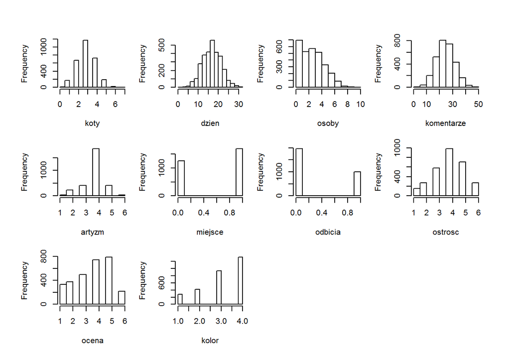

```r
par(mfrow=c(3,4), mar=c(4,4,2,1), oma=rep(2,4))
for(i in 1:ncol(zdjecia0)){
    hist(zdjecia0[,i],xlab = colnames(zdjecia0)[i],main = "")
}
```

Korelacja spearmana pomiedzy wszystkimi zmiennymi.

```r
round(cor(zdjecia0, method = c("spearman")), 2)
```

```
##             koty dzien osoby komentarze artyzm miejsce odbicia ostrosc
## koty        1.00  0.02 -0.27      -0.19  -0.17    0.18    0.14   -0.16
## dzien       0.02  1.00  0.24      -0.19  -0.18   -0.25    0.11    0.30
## osoby      -0.27  0.24  1.00       0.32   0.28    0.29   -0.19    0.08
## komentarze -0.19 -0.19  0.32       1.00   0.86    0.26   -0.30   -0.24
## artyzm     -0.17 -0.18  0.28       0.86   1.00    0.23   -0.28   -0.22
## miejsce     0.18 -0.25  0.29       0.26   0.23    1.00   -0.17   -0.02
## odbicia     0.14  0.11 -0.19      -0.30  -0.28   -0.17    1.00   -0.15
## ostrosc    -0.16  0.30  0.08      -0.24  -0.22   -0.02   -0.15    1.00
## ocena       0.35 -0.41 -0.06       0.16   0.16    0.22   -0.07   -0.13
## kolor       0.08  0.10  0.01      -0.36  -0.31    0.04   -0.02    0.30
##            ocena kolor
## koty        0.35  0.08
## dzien      -0.41  0.10
## osoby      -0.06  0.01
## komentarze  0.16 -0.36
## artyzm      0.16 -0.31
## miejsce     0.22  0.04
## odbicia    -0.07 -0.02
## ostrosc    -0.13  0.30
## ocena       1.00 -0.18
## kolor      -0.18  1.00
```

Korelacja Pearsona pomiedzy wszystkimi zmiennymi.

```r
round(cor(zdjecia0, method = c("pearson")),2)
```

```
##             koty dzien osoby komentarze artyzm miejsce odbicia ostrosc
## koty        1.00  0.03 -0.28      -0.20  -0.18    0.18    0.14   -0.16
## dzien       0.03  1.00  0.24      -0.21  -0.20   -0.25    0.12    0.31
## osoby      -0.28  0.24  1.00       0.32   0.28    0.29   -0.20    0.08
## komentarze -0.20 -0.21  0.32       1.00   0.90    0.26   -0.30   -0.25
## artyzm     -0.18 -0.20  0.28       0.90   1.00    0.23   -0.28   -0.22
## miejsce     0.18 -0.25  0.29       0.26   0.23    1.00   -0.17   -0.03
## odbicia     0.14  0.12 -0.20      -0.30  -0.28   -0.17    1.00   -0.15
## ostrosc    -0.16  0.31  0.08      -0.25  -0.22   -0.03   -0.15    1.00
## ocena       0.35 -0.41 -0.06       0.16   0.15    0.22   -0.08   -0.13
## kolor       0.09  0.11  0.01      -0.36  -0.31    0.04   -0.01    0.30
##            ocena kolor
## koty        0.35  0.09
## dzien      -0.41  0.11
## osoby      -0.06  0.01
## komentarze  0.16 -0.36
## artyzm      0.15 -0.31
## miejsce     0.22  0.04
## odbicia    -0.08 -0.01
## ostrosc    -0.13  0.30
## ocena       1.00 -0.18
## kolor      -0.18  1.00
```

Nalezy wyróznic korelacje pomiedzy zmiennymi komentarz oraz artyzm, która jest najwieksza co do wartosci bezwzglednej - 0.8980848. Relacja ta wydaje sie racjonalna. Druga korelacja warta wyróznienia jest relacja pomiedzy dniem miesiaca publikacji oraz ocena. Interpretacja tego wspólczynnika ukazuje potencjal publikowania zdjec na poczatku miesiaca. Nalezy zaznaczyc ze zmienna dla dnia publikacji ma charakterystyki wskazujace na rozklad istotnie normalny.

Testy na istotnosc pozwalaja na odrzucenie hipotezy zerowej zakladajacej korelacje równa zeru.

*TESTY NA ISTOTNOSC DWÓCH NAJBARDZIEJ INTERESUJACYCH KORELACJI ZAPREZENTOWANO NA DRUGIEJ STRONIE

```r
cor.test(as.numeric(zdjecia0$artyzm),as.numeric(zdjecia0$komentarze),method = c("pearson"))
```

```
##
##  Pearson's product-moment correlation
##
## data:  as.numeric(zdjecia0$artyzm) and as.numeric(zdjecia0$komentarze)
## t = 111.07, df = 2959, p-value < 2.2e-16
## alternative hypothesis: true correlation is not equal to 0
## 95 percent confidence interval:
##  0.8908837 0.9048346
## sample estimates:
##       cor
## 0.8980848
```

```r
cor.test(as.numeric(zdjecia0$ocena),as.numeric(zdjecia0$dzien),method = c("spearman"))
```

```
##
##  Spearman's rank correlation rho
##
## data:  as.numeric(zdjecia0$ocena) and as.numeric(zdjecia0$dzien)
## S = 6081800000, p-value < 2.2e-16
## alternative hypothesis: true rho is not equal to 0
## sample estimates:
##        rho
## -0.4056195
```

## Canonical Correlations

Stworzono zmienne konieczne do przeprowadzenia analizy.Kryterium doboru zmiennych bylo narzucone z góry.

```r
zbior1<-c("artyzm", "ostrosc", "ocena")
zbior2<-c("kolor2","kolor3","kolor4","koty", "miejsce2", "odbicia2", "dzien", "osoby")
matY<-zdjecia02[,zbior1]
matX<-zdjecia02[,zbior2]
corrall<-matcor(matX,matY)
corrall$XYcor
```

```
##                 kolor2      kolor3      kolor4        koty     miejsce2
## kolor2    1.0000000000 -0.27676090 -0.36261720 -0.01568453 -0.007554501
## kolor3   -0.2767609033  1.00000000 -0.61225761 -0.01520725 -0.017777133
## kolor4   -0.3626171977 -0.61225761  1.00000000  0.07232030  0.037196226
## koty     -0.0156845282 -0.01520725  0.07232030  1.00000000  0.182786069
## miejsce2 -0.0075545010 -0.01777713  0.03719623  0.18278607  1.000000000
## odbicia2 -0.0225184220  0.02943472 -0.02235972  0.14026794 -0.165036439
## dzien    -0.0448402407 -0.01317768  0.09018178  0.02574509 -0.250060550
## osoby    -0.0003863498 -0.02022860  0.01873075 -0.28194470  0.286915235
## artyzm    0.1163630200  0.08690286 -0.28245211 -0.18057792  0.231579762
## ostrosc  -0.1198801629 -0.06119485  0.26504809 -0.16037719 -0.025652641
## ocena     0.0819312058  0.03668024 -0.15883778  0.35400384  0.224193457
##             odbicia2       dzien         osoby      artyzm     ostrosc
## kolor2   -0.02251842 -0.04484024 -0.0003863498  0.11636302 -0.11988016
## kolor3    0.02943472 -0.01317768 -0.0202285993  0.08690286 -0.06119485
## kolor4   -0.02235972  0.09018178  0.0187307472 -0.28245211  0.26504809
## koty      0.14026794  0.02574509 -0.2819447044 -0.18057792 -0.16037719
## miejsce2 -0.16503644 -0.25006055  0.2869152345  0.23157976 -0.02565264
## odbicia2  1.00000000  0.11917154 -0.1993564115 -0.27839121 -0.14752440
## dzien     0.11917154  1.00000000  0.2376557400 -0.19518259  0.31168792
## osoby    -0.19935641  0.23765574  1.0000000000  0.28336508  0.08392537
## artyzm   -0.27839121 -0.19518259  0.2833650768  1.00000000 -0.22461926
## ostrosc  -0.14752440  0.31168792  0.0839253673 -0.22461926  1.00000000
## ocena    -0.07538635 -0.41102732 -0.0603780705  0.15013748 -0.12761502
##                ocena
## kolor2    0.08193121
## kolor3    0.03668024
## kolor4   -0.15883778
## koty      0.35400384
## miejsce2  0.22419346
## odbicia2 -0.07538635
## dzien    -0.41102732
## osoby    -0.06037807
## artyzm    0.15013748
## ostrosc  -0.12761502
## ocena     1.00000000
```

W macierzy nie mozna wyróznic istotnej ilosci duzych co do wartosci bezwzglednej korelacji.

```r
cc1 <- cc(matX,matY)
# sklad oraz rodzaje wynikow dla funkcji cc
str(cc1)
```

```
## List of 5
##  $ cor   : num [1:3] 0.699 0.515 0.256
##  $ names :List of 3
##   ..$ Xnames   : chr [1:8] "kolor2" "kolor3" "kolor4" "koty" ...
##   ..$ Ynames   : chr [1:3] "artyzm" "ostrosc" "ocena"
##   ..$ ind.names: chr [1:2961] "1" "2" "3" "4" ...
##  $ xcoef : num [1:8, 1:3] 0.49 0.765 1.352 -0.613 0.162 ...
##   ..- attr(*, "dimnames")=List of 2
##   .. ..$ : chr [1:8] "kolor2" "kolor3" "kolor4" "koty" ...
##   .. ..$ : NULL
##  $ ycoef : num [1:3, 1:3] -0.128 0.416 -0.511 -1.235 -0.259 ...
##   ..- attr(*, "dimnames")=List of 2
##   .. ..$ : chr [1:3] "artyzm" "ostrosc" "ocena"
##   .. ..$ : NULL
##  $ scores:List of 6
##   ..$ xscores       : num [1:2961, 1:3] -2.389 -0.137 -0.575 1.469 -1.414 ...
##   .. ..- attr(*, "dimnames")=List of 2
##   .. .. ..$ : chr [1:2961] "1" "2" "3" "4" ...
##   .. .. ..$ : NULL
##   ..$ yscores       : num [1:2961, 1:3] -1.334 -0.472 -0.662 1.8 -2.166 ...
##   .. ..- attr(*, "dimnames")=List of 2
##   .. .. ..$ : chr [1:2961] "1" "2" "3" "4" ...
##   .. .. ..$ : NULL
##   ..$ corr.X.xscores: num [1:8, 1:3] -0.1961 -0.0988 0.4136 -0.4723 -0.2941 ...
##   .. ..- attr(*, "dimnames")=List of 2
##   .. .. ..$ : chr [1:8] "kolor2" "kolor3" "kolor4" "koty" ...
##   .. .. ..$ : NULL
##   ..$ corr.Y.xscores: num [1:3, 1:3] -0.2359 0.4539 -0.5804 -0.4782 -0.0617 ...
##   .. ..- attr(*, "dimnames")=List of 2
##   .. .. ..$ : chr [1:3] "artyzm" "ostrosc" "ocena"
##   .. .. ..$ : NULL
##   ..$ corr.X.yscores: num [1:8, 1:3] -0.1371 -0.0691 0.2891 -0.3301 -0.2056 ...
##   .. ..- attr(*, "dimnames")=List of 2
##   .. .. ..$ : chr [1:8] "kolor2" "kolor3" "kolor4" "koty" ...
##   .. .. ..$ : NULL
##   ..$ corr.Y.yscores: num [1:3, 1:3] -0.338 0.649 -0.83 -0.928 -0.12 ...
##   .. ..- attr(*, "dimnames")=List of 2
##   .. .. ..$ : chr [1:3] "artyzm" "ostrosc" "ocena"
##   .. .. ..$ : NULL
```

## Zinterpretuj powiazania miedzy zbiorami zmiennych, analizujac wielkosci standaryzowanych wag kanonicznych i ladunków czynnikowych. Czy wystepuja róznice? Jakie? Interpretacja powinna byc przeprowadzona jedynie dla istotnych korelacji kanonicznych.

Warto ukazac najwazniejsze wyniki otrzymane z funkcji cc.

```r
cc1$cor
```

```
## [1] 0.6990544 0.5150777 0.2562271
```

```r
cc1$ycoef
```

```
##               [,1]       [,2]        [,3]
## artyzm  -0.1279292 -1.2347593  0.08647124
## ostrosc  0.4162045 -0.2591983 -0.64425872
## ocena   -0.5112507  0.1089434 -0.45933313
```

```r
cc1$xcoef
```

```
##                 [,1]         [,2]        [,3]
## kolor2    0.49035541  0.381268557 -0.63996095
## kolor3    0.76498349  0.461841462 -1.00481407
## kolor4    1.35169665  1.053796889 -1.64884308
## koty     -0.61258763  0.428457319 -0.41732511
## miejsce2  0.16208561 -0.630496519 -0.55895285
## odbicia2 -0.06930292  0.974533662  1.30897499
## dzien     0.16929266 -0.009423395 -0.01496501
## osoby    -0.16269409 -0.171015591  0.03798971
```

Pierwszy wspólczynnik korelacj kanonicznej jest równy 0.6990544 - i.e. najwiekszy mozliwy do osiagniecia wspólczynnik otrzymany z liniowyej kombinacji zmiennych z obu badanych zbiorow. Zgodnie z oczekiwaniami policzony wspólczynnik jest wiekszy niz dowolny wspólczynnik z macierzy korelacji miedzy zmienna ze zbioru X, a zmienna ze zbioru Y.

Poniewaz zmienne ukazano na róznych skalach oraz maja rózna wariancje powinnismy analizowac “wystandaryzowane wagi kanoniczne”. Róznica w interpretacji polega jedynie na zmianie miar zmian danej zmiennej.

### Standardized Canonical Coefficients

```r
wyniki<-list()
wyniki[[1]] <- diag(sqrt(diag(cov(matY)))) %*% cc1$ycoef
rownames(wyniki[[1]])<-rownames(cc1$ycoef)
wyniki[[2]] <- diag(sqrt(diag(cov(matX)))) %*% cc1$xcoef
rownames(wyniki[[2]])<-rownames(cc1$xcoef)
wyniki
```

```
## [[1]]
##               [,1]       [,2]        [,3]
## artyzm  -0.1063451 -1.0264315  0.07188187
## ostrosc  0.5300802 -0.3301163 -0.82053126
## ocena   -0.7466721  0.1591099 -0.67084741
##
## [[2]]
##                 [,1]        [,2]        [,3]
## kolor2    0.17059743  0.13264550 -0.22264605
## kolor3    0.35645395  0.21520100 -0.46820611
## kolor4    0.67187838  0.52380343 -0.81957887
## koty     -0.63026500  0.44082126 -0.42936781
## miejsce2  0.08019321 -0.31194341 -0.27654659
## odbicia2 -0.03278925  0.46108061  0.61931467
## dzien     0.77085433 -0.04290833 -0.06814142
## osoby    -0.31072910 -0.32662232  0.07255647
```

Analizujemy kilka losowych zmiennych o najwyzszych co do wartosci bezwglednej wartosciach wspólczynników. Nelezy zaznaczyc ze wyniki mozna analizowac dwukierunkowo. Przemnozenie stron przez minus jeden powoduje odwrócenie wnioskowania przy zachowaniu wiarygodnosci interpretacji.

Druga zmienna kanoniczna – slabe walory artystyczne (-1.0264315) - kolor – kolor inny niz zielony niebieksi i filetowy powinien wplywac ujemnie na walory artystyczne zdjecia - koty – wiecej kotów to gorsza wartosc artystyczna

Trzecia zmienna kanoniczna – slaba ostrosc oraz slaba ocena - kolor – kolor inny niz zielony niebieksi i filetowy powinien wplywac dodatnio na ostrosc i/lub ocene - odbicia – wystepowanie odbicia powinien wplywac ujemnie na ostrosc i/lub ocene

### Ile par zmiennych kanonicznych wybrac?

Procedura Liczenia lambdy WILKSA powinna ulatwic analize wiekszych zbiorów danych - i.e. wyboru istotnych zmiennych kanonicznych do dalszej analizy.

```r
WILKSL<-function(matX,matY,cc1){
ev <- (1 - cc1$cor^2)
n <- dim(matX)[1]
p <- length(matX)
q <- length(matY)
k <- min(p, q)
m <- n - 3/2 - (p + q)/2
w <- rev(cumprod(rev(ev)))
# initialize
d1 <- d2 <- f <- vector("numeric", k)

for (i in 1:k) {
    s <- sqrt((p^2 * q^2 - 4)/(p^2 + q^2 - 5))
    si <- 1/s
    d1[i] <- p * q
    d2[i] <- m * s - p * q/2 + 1
    r <- (1 - w[i]^si)/w[i]^si
    f[i] <- r * d2[i]/d1[i]
    p <- p - 1
    q <- q - 1
}
pv <- pf(f, d1, d2, lower.tail = FALSE)
dmat <- cbind(WilksL = w, F = f, df1 = d1, df2 = d2, p = pv)
return(dmat)
## source: http://www.ats.ucla.edu/stat/r/dae/canonical.htm
}
```

FUNKCJA DO SZYBKIEGO POLICZENIA LAMBDY WILKSA

```r
WILKS2<-function(cc1){
    dmat2<-matrix(0,nrow=ncol(matY),ncol=2)
    sapply(1:ncol(matY),function(i) dmat2[i,1]<<-prod((1-cc1$cor^2)[i:(ncol(matY))]))
    return(dmat2)
}
```

Testowanie istotnosci koreacji kanonicznych dla analizowanych danych.

```r
WILKSL(matX,matY,cc1)
```

```
##         WilksL         F df1      df2             p
## [1,] 0.3510030 154.99349  24 8556.499  0.000000e+00
## [2,] 0.6864606  87.24763  14 5902.000 2.001233e-228
## [3,] 0.9343477  34.57059   6 2952.000  1.417238e-40
```

```r
WILKS2(cc1)
```

```
##           [,1] [,2]
## [1,] 0.3510030    0
## [2,] 0.6864606    0
## [3,] 0.9343477    0
```

### Wspólczynnik redundancji

Redundacja mowi nam ile przecietnie wariancji w jednym zbiorze jest wyjasnione przez dana zmienna kanoniczna przy danym innym zbiorze zmiennych. Wartosc redundacji calkowitej moze byc wazna analityczna informacja o naszym modelu. Mowi o procencie calkowitej wariancji jednego zbioru wyjasniona w ramach modelu.

```r
REDUNT<-function(matX,matY,cc1){
    eigenmatY<-cc1$cor
    vector1<-vector(,length(matY))
    sapply(1:ncol(matY),function(i) vector1[i]<<-sqrt(eigenmatY[i]))
    names1<-c("opposite variance","own variance")
    names2<-c("prop stdvar v","prop stdvar u")
    matim<<-list()
    for(i in (1:ncol(matY))){
        a<-round(sum((cc1$scores$corr.Y.xscores[,i])^2)/ncol(matY),3)
        b<-round(a/vector1[i],3)
        c<-round(sum((cc1$scores$corr.X.yscores[,i])^2)/ncol(matX),3)
        d<-round(c/vector1[i],3)
        assign(paste0("amat",i),matrix(c(c,d,a,b),byrow=TRUE,nrow=2,ncol=2,dimnames=list(names2,names1)),inherit=TRUE)
        matim[[i]]<<-get(paste0("amat",i))
    }
    return(matim)
}
```

Zastosotanie funkcji REDUNT

```r
REDUNT(matX,matY,cc1)
```

```
## [[1]]
##               opposite variance own variance
## prop stdvar v             0.063        0.075
## prop stdvar u             0.200        0.239
##
## [[2]]
##               opposite variance own variance
## prop stdvar v             0.047        0.065
## prop stdvar u             0.078        0.109
##
## [[3]]
##               opposite variance own variance
## prop stdvar v             0.009        0.018
## prop stdvar u             0.020        0.040
```

## Sprawdz, czy w zbiorze danych wystepuja obserwacje odstajace i okresl, czy budza one podejrzenia. Jako etykiety mozesz uzyc zmiennej nr zdjecia.

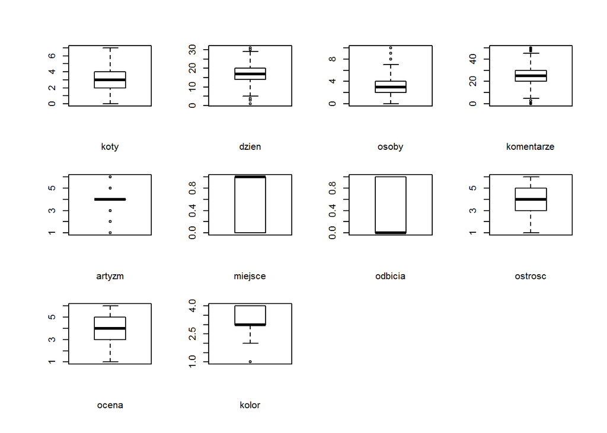

```r
par(mfrow=c(3,4), mar=c(4,4,2,1), oma=rep(2,4))
for(i in 1:ncol(zdjecia0)){
    boxplot(zdjecia0[,i],xlab = colnames(zdjecia0)[i],main = "")
}
```

```r
outliers<-list()
for(i in 1:ncol(zdjecia0)){
  tt<-zdjecia0[which(zdjecia0[,i]>stats[6,i]),]
  outliers[[i]]<-tt
}
  names(outliers)<-c(colnames(zdjecia0))
```

OUTLIERS

```r
outliers[1:4]
```

```
## $koty
##      koty dzien osoby komentarze artyzm miejsce odbicia ostrosc ocena
## 2586    7    21     0         18      3       1       1       4     5
##      kolor
## 2586     3
##
## $dzien
##      koty dzien osoby komentarze artyzm miejsce odbicia ostrosc ocena
## 478     4    31     5         24      4       0       0       5     2
## 539     2    31     6         22      4       0       0       4     1
## 2249    3    31     5         18      3       0       0       6     1
## 2378    3    31     5         15      2       0       1       5     1
##      kolor
## 478      3
## 539      2
## 2249     3
## 2378     4
##
## $osoby
##      koty dzien osoby komentarze artyzm miejsce odbicia ostrosc ocena
## 201     1    15     9         32      4       1       0       4     3
## 270     3    18    10         27      4       1       0       4     3
## 1025    3    16     9         34      5       1       0       2     5
## 1048    1    19     9         31      4       1       0       4     3
## 2287    2    20     9         38      5       1       0       4     3
## 2336    0    19     9         27      4       1       0       5     2
## 2934    1    12     9         39      5       1       0       2     3
##      kolor
## 201      3
## 270      4
## 1025     4
## 1048     4
## 2287     3
## 2336     3
## 2934     2
##
## $komentarze
##      koty dzien osoby komentarze artyzm miejsce odbicia ostrosc ocena
## 5       4    21     7         49      6       1       0       1     5
## 459     1    11     4         49      6       1       0       3     5
## 740     1     9     6         47      6       1       0       4     5
## 851     2     9     4         50      6       1       0       2     4
## 2635    4    15     3         48      6       1       1       1     4
##      kolor
## 5        1
## 459      1
## 740      2
## 851      1
## 2635     1
```